COMS W4111-002, Fall 21:  
Take Home Midterm

# Overview

## Instructions

#### Due Date: Sunday, October 31, 2021 at 11:59pm

You have one week to complete the take home portion of the midterm. All of the work must be your own, you may not work in groups or teams. You may use outside sources so long as you cite them and provide links.

Points will be taken off for any answers that are extremely verbose. Try to stay between 2-3 sentences for definitions and 5 sentences for longer questions.

You may post **privately** on Ed or attend OH for clairification questions. TAs will not be providing hints.

## Environment Setup

- **Note:** You will need to change the MySQL userID and password in some of the cells below to match your configuration.

```python
%load_ext sql
```

```python
%sql mysql+pymysql://dbuser:dbuserdbuser@localhost
```

```
'Connected: dbuser@None'
```

```python
from sqlalchemy import create_engine
```

```python
sql_engine = create_engine("mysql+pymysql://dbuser:dbuserdbuser@localhost")
```

```python
import pandas as pd
```

# Written Questions

## W1

Provide a short (two or three sentence) definition/description of the following terms. Provide an example from the Lahman's Baseball DB for each.

**Notes:**

Answer

# W2

- Define the concept of *immutable* column and key.

An immutable column and key would not be modified once it is created. A new record or a column needs to be inserted if there is a modification to the data

- Why do some sources recommend that a primary key should be immutable?

Valeus in Primary key can be used across tables as foreign keys usually reference this data. Any change would need to be propogated throughout the database, hence it is advised to make the P.K. immutable. This prevents the chance of orphan records.

- How would to implement immutability for a primary key in a table? We can add the constrain ON UPDATE RESTRICT to the Primary key to make it immutable.

Answer

# W3

*Views* are a powerful concept in relational database management systems. List and briefly explain 3 benefits of/reasons for creating a view.

- Views can help to control the degree of exposure of the underlying tables to the outer world. A user may have permission to query the view, while denied access to the rest of the base table.
- They can join multiple tables into a single vitual table and simplify working with them.
- Views do not take up much space to store since database contains only the definition of a view, not a copy of all the data

# W4

Briefly explain the concepts of *procedural* language and *declarative* language. SQL is a declarative language. What are some advantages of a declarative language over a procedural language?

In a procedural language you define each step in detail, whereas in a declarative language you provide a command and get your result via a black-box method. In the declarative style you do not need to know about the underlying structure, while can still carry out the operations from a high level abstraction.

# W5

The following diagram is a simple representation of the architecture of a Jupyter notebook using MySQL. Is this a two-tier architecture or a three-tier architecture? Explain your answer briefly.

[figure not shown]

The above diagram is an example of a 3 layer architecture. The browser can be termed as a client or the user interface, the Notebook is the data processing layer and the Kernel is the data storage layer.

# W6

What is the difference between the database schema and the database instance? Use the following conventions of the relational model for documenting a relation schema to answer the question if:

1. $country\_code$ is the country code for the phone number, e.g. +1
2. $main\_number$ is the main number, e.g. 212-555-1212.
3. $extension$ is the extension, e.g. x1002
4. $phone\_type$ is an enum, e.g. *work, home, mobile, others.*

\begin{equation} PhoneNumber(\underline{country\_code)}, \underline{main\_number}, \underline{extension}, phone\_type) \end{equation}

The main difference between schema and instance is that schema is a structural view of the database, while the instance is the data stored in a database at a particular moment of time. For the example, schema is the structure like data type of country code, possiblle values in the enum phone_type or the length of the main_number. The instance is the record stored: +1, 212-555-1212, x1002, work

# W7

Briefly explain the differences between:

- Database stored procedure A procedure is a combination of SQL statements written to perform a specified tasks. It helps in code re-usability and saves time and lines of code.
- Database function A database function is a specialised procedure that is pre-defined, it takes in a set of values to give an output.
- Database trigger A trigger is a special kind of procedure which executes only when some triggering event such as INSERT, UPDATE, DELETE operations occurs in a table.

The difference is procedures can be user-defined, database functions are pre-defined and triggers work on the execution of an event.

# W8

Briefly explain:

- Natural join
- Equi-join
- Theta join
- Self-join
- Equi-join: It type of join in which only can only use the equality operator and does so on the columns that are specified.
- Natural join: A natural join is an equi-join on attributes that have the same name. It only compares the same name columns.
- Theta join: A theta join allows for various comparison relationships like >, <, = etc.
- Self-join: When a table is joined with itself.

# W9

Briefly explain the difference between a *unique (key) constraint* and a *primary key constraint?*

The unique key constraint allows for non-duplicate values along with a single NULL value whereas primary key column cannot contain a null value. It only contains unique values.

# W10

Briefly explan *domain constraint* and give an example.

Domain Constraints defines the domain of all the possible values that the attribute can take. For eg: We can specify the ranges of value a column take. Like a check can be placed to have salary > 20000. The constraint will make sure that all values entered satisfy this or will give an error.

# Entity Relationship Model

Question

- This question tests transforming a high-level description of a data model into a more concrete logical ER diagram. You will produce a logical ER-diagram using Lucidchart, or a similar tool. You should use Crow's Foot notation and conventions we have used in lectures.
- The data model is a simple representation of a university.
- The model has the following entity types.
  - School:
    - School code, e.g. "SEAS," "GSAS," "LAW," ... ...
    - School name, e.g. "School of Engineering and Applied Science."
  - Department:
    - Department code, e.g. "COMS," "MATH," "ECON," ... ...
    - Department name, e.g. "Department of Computer Science."
  - Faculty:
    - UNI
    - last_name
    - first_name
    - email
    - title, e.g. "Professor," "Adjunct Professor," ... ...
  - Student:
    - UNI
    - last_name
    - first_name
    - email
  - Course:
    - Course number is a composite key, e.g. "COMSW4111" is
      - Dept. code "COMS"
      - Faculty code "W"
      - Course number "4111"
    - Course title
    - Course description
  - Section:
    - Call number
    - Course number
    - Year
    - Semester
    - Section
- A Faculty has complex states and relationships.
  - A Faculty can have a role relative to a Department, e.g. Chair.
  - Roles are a small set of possible values.
  - Roles change over time. The data model must support the ability to handle current roles and previous roles.
  - A Faculty can have a role in a department at most once.
- A Student has a relationship to Section.
  - The possible roles are `(Enrolled, Waitlist, Dropped, TA)`
  - The student has a current role, and there can be only one current row.
  - The data model must support the ability to handle roles changing over time and retaining information about prior roles.
- A Faculty *may* teach a Section. All sections have exactly one Faculty.
- The relationship between Department and School is many-to-many. Each Department is in at least one school and each school has at least one department.

**Notes:**

1. There is no single correct answer to this question. You will have to make some design decisions and assumptions. You should document your decisions and assumptions.
2. You do not have to worry about **isA** relationships.
3. You do not have to document or worry about attribute types.
4. The ER diagram must be implementable in the relational/SQL model.

Answer

*Assumptions, Decsions and Notes:*

1. Faculty may teach 0, 1 or many sections.
2. Section can have 1 or many students

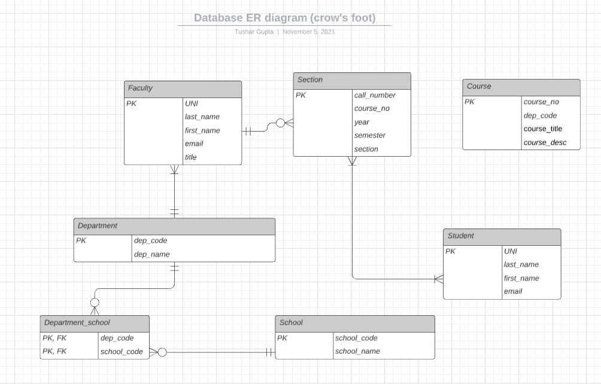

```python
from IPython.display import Image
Image('./q2.png')
```

# Relational Algebra

## R1

Use the [RelaX Calculator and the Silberschatz - UniversityDB](https://dbis-uibk.github.io/relax/calc/gist/4f7866c17624ca9dfa85ed2482078be8/relax-silberschatz-english.txt/0) for this question.

Two time slots *X* and *Y* obviously overlap if:

1. They are not the same time slot, i.e. do not have the same $time\_slot\_id$.
2. They have at least one lecture on *the same day,* the start hour for *X* is before the start hour for *Y*, and the end hour for *X* is after the start hour for *Y.*
3. To make the question easier, you do not need to consider minutes in computing overlap but must show minutes in the result.

Write the relational algebra expression that identifies obviously overlapping time slots, and only lists overlapping pairs of time slots once.

Your output must match the answer below.

[figure not shown]

σ (X.time_slot_id ≠ Y.time_slot_id) ∧ (X.start_hr < Y.start_hr) ∧ (X.end_hr > Y.end_hr) ∧ (X.day = Y.day) (ρ X (time_slot) ⨯ ρ Y (time_slot))

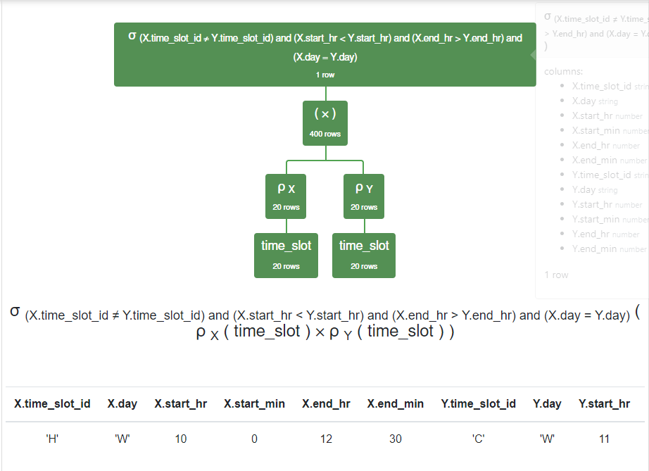

## R2

1. You **may not** use the subtraction operator `-` to write this query.
2. Produce a relation that:
   - Has column names `instructor_ID, instructor_name.`
   - Contains the `ID` and `name` of instructors who do not advise any students.

π instructor_ID ← instructor.ID, instructor_name ← instructor.name (instructor ▷ (instructor.ID = advisor.i_id) advisor)

[figure not shown]

# SQL Schema and DDL

### Objective

- You have a logical datamodel ER-diagram (see below).
- You need to use DDL to define a schema that realizes the model.
- Logical models are not specific enough for direct implementation. This means that:
  - You will have to assign concrete types to columns, and choose things like `GENERATED,` `DEFAULT,` etc.
  - You may have to decompose a table into two tables, or extract common attributes from multiple tables into a single, referenced table.
  - Implementing the relationships may require adding columns and foreign keys, associative entities, etc.
  - You may have to make other design and implementation choices. **This means that there is no single correct answer.**

### ER Diagram

| **ER Diagram** |
| --- |

Answer

*Design Decisions, Notes, etc.*

*DDL*

- Execute your DDL in the cell below. You may use DataGrip or other tools to help build the schema.
- You can copy and paste the `SQL CREATE TABLE` below, but you MUST execute the statements.

```
create table appointment
(
    appt_ID       int          not null
        primary key,
    appt_date     date         null,
    appt_time     timestamp    null,
    appt_duration int          null,
    appt_reason   varchar(255) null,
    physician_ID  int          null,
    patient_ID    int          null,
    bill_no       int          null,
    constraint appointment_bill_no_uindex
        unique (bill_no),
    constraint appointment_bill_bill_no_fk
        foreign key (bill_no) references bill (bill_no),
    constraint appointment_patient_patient_ID_fk
        foreign key (patient_ID) references patient (patient_ID),
    constraint appointment_physician_physician_ID_fk
        foreign key (physician_ID) references physician (physician_ID)
);

create table bill
(
    bill_no            int         not null
        primary key,
    amount_insured     float       null,
    amount_not_insured float       null,
    bill_total         float       null,
    bill_date          date        null,
    bill_status        varchar(20) null
);

create table insurance_company
(
    company_id     int          not null
        primary key,
    insured_person varchar(255) null,
    phone_no       int          null,
    street1        varchar(255) null,
    city           varchar(100) null,
    state          varchar(100) null,
    postal_code    int          null
);

create table patient
(
    patient_ID  int          not null
        primary key,
    last_name   varchar(100) null,
    first_name  varchar(100) null,
    street1     varchar(255) null,
    city        varchar(100) null,
    state       varchar(100) null,
    postal_code int          null,
    company_id  int          null,
    constraint patient_insurance_company_company_id_fk
        foreign key (company_id) references insurance_company (company_id)
);

create table payment
(
    receipt_no  int         not null
        primary key,
    paid_amount float       null,
    paid_date   date        null,
    paid_type   varchar(20) null,
    company_id  int         null,
    bill_no     int         null,
    patient_id  int         null,
    constraint payment_bill_bill_no_fk
        foreign key (bill_no) references bill (bill_no),
    constraint payment_insurance_company_company_id_fk
        foreign key (company_id) references insurance_company (company_id),
    constraint payment_patient_patient_ID_fk
        foreign key (patient_id) references patient (patient_ID)
);

create table physician
(
    physician_ID   int          not null
        primary key,
    last_name      varchar(100) null,
    first_name     varchar(100) null,
    physician_type varchar(5)   null
);
```

## Complex SQL

### Birth Countries and Death Countries

Question

- In `lahmansbaseballdb.people` there is information about people's `birthCountry` and `deathCountry.`
- There are countries in which at least person was born but in which no person has died.
- Write a query that produces a table of the form:
  - `birthCountry`
  - `no_of_births`, which is the total number of births in the country
- The table contains all rows in which there with births but no deaths.

Answer

```python
import pymysql
import pandas as pd
conn=pymysql.connect(host='localhost',port=int(3306),user='root',passwd='admin123', db = 'lahmansbaseballdb')
pd.read_sql_query("select birthCountry, count(*) as no_of_births from \
                                                   lahmansbaseballdb.people \
where birthCountry not in (select distinct(deathCountry) from lahmansbaseballdb.people where deathCountry is not NULL) group by birthCountry order by no_of_births DESC;", conn)
```

|  | birthCountry | no_of_births |
| --- | --- | --- |
| 0 | Germany | 45 |
| 1 | Colombia | 24 |
| 2 | South Korea | 23 |
| 3 | Curacao | 15 |
| 4 | Nicaragua | 15 |
| 5 | Russia | 9 |
| 6 | Italy | 7 |
| 7 | Czech Republic | 6 |
| 8 | Aruba | 5 |
| 9 | Poland | 5 |
| 10 | Brazil | 5 |
| 11 | Sweden | 4 |
| 12 | Jamaica | 4 |
| 13 | Spain | 4 |
| 14 | Norway | 3 |
| 15 | South Africa | 2 |
| 16 | Saudi Arabia | 2 |
| 17 | Honduras | 2 |
| 18 | Guam | 2 |
| 19 | Hong Kong | 1 |
| 20 | Afghanistan | 1 |
| 21 | Denmark | 1 |
| 22 | Switzerland | 1 |
| 23 | Singapore | 1 |
| 24 | Belgium | 1 |
| 25 | Peru | 1 |
| 26 | Belize | 1 |
| 27 | Indonesia | 1 |
| 28 | Finland | 1 |
| 29 | Lithuania | 1 |
| 30 | Viet Nam | 1 |
| 31 | Slovakia | 1 |
| 32 | Greece | 1 |
| 33 | Portugal | 1 |
| 34 | Latvia | 1 |

### Best Baseball Players

Question

- This question uses `lahmansbaseballdb.batting`, `lahmansbaseballdb.pitching` and `lahmansbaseballdb.people`.
- There query computes performance metrics:
  - Batting:
    - On-base percentage: OBP is (sum(h) + sum(BB))/(sum(ab) + sum(BB))
    - Slugging percentage: SLG is

      ```
      (
      (sum(h) - sum(`1b`) - sum(`2b`) - sum(`3b`) - sum(hr)) +
      2*sum(`2b`) + 3*sum(`3b`) + 4*hr
      )/sum(ab)
      ```

Answer

```python
import pymysql
import pandas as pd
conn=pymysql.connect(host='localhost',port=int(3306),user='root',passwd='admin123', db = 'lahmansbaseballdb')
pd.read_sql_query("with batting_cal as \
(select playerID, OBP, SLG, OBP + SLG as OPS, total_AB from (select playerID, (SUM(H) + SUM(BB)) / (SUM(AB) + SUM(BB)) as OBP, \
       (((sum(H) - sum(2B) - sum(3b) - sum(HR)) + 2*sum(2B) + 3*sum(3B) + 4*sum(HR))/sum(AB)) as SLG, SUM(AB) AS total_AB \
       from batting group by playerID) as t1) \
, pitching_cal as \
    (select playerID, sum(w) as total_wins, \
           sum(l) as total_losses, \
           ((sum(w)) / (sum(w) + sum(l))) as win_percentage from pitching group by playerID) \
, batting_criteria as \
    (select * from batting_cal where OPS >= 1.0 and total_AB >=1000) \
, pitching_criteria as \
    (select * from pitching_cal where total_losses + total_wins>= 200 and (total_wins >=300 or win_percentage>=70)) \
, join_table as \
    ( select * from people \
        LEFT JOIN batting_criteria using(playerID) \
        LEFT JOIN pitching_criteria using(playerID)) \
, filter_table as \
    ( select * from join_table where total_AB is not NULL or total_wins is not NUll) \
select playerID, nameFirst, nameLast, debut_date, finalgame_date, OPS, OBP, SLG, total_wins, total_losses, win_percentage, \
       (CASE \
           WHEN OPS is not NULL THEN 'Batter' \
           ELSE 'Pitcher' \
       END) as great_because from filter_table; \
", conn)
```

|  | playerID | nameFirst | nameLast | debut_date | finalgame_date | OPS | OBP | SLG | total_wins | total_losses | win_percentage | great_because |
| --- | --- | --- | --- | --- | --- | --- | --- | --- | --- | --- | --- | --- |
| 0 | alexape01 | Pete | Alexander | 1911-04-15 | 1930-05-28 | NaN | NaN | NaN | 373.0 | 208.0 | 0.6420 | Pitcher |
| 1 | bondsba01 | Barry | Bonds | 1986-05-30 | 2007-09-26 | 1.0497 | 0.4428 | 0.6069 | NaN | NaN | NaN | Batter |
| 2 | carltst01 | Steve | Carlton | 1965-04-12 | 1988-04-23 | NaN | NaN | NaN | 329.0 | 244.0 | 0.5742 | Pitcher |
| 3 | clarkjo01 | John | Clarkson | 1882-05-02 | 1894-07-12 | NaN | NaN | NaN | 328.0 | 178.0 | 0.6482 | Pitcher |
| 4 | clemero02 | Roger | Clemens | 1984-05-15 | 2007-09-16 | NaN | NaN | NaN | 354.0 | 184.0 | 0.6580 | Pitcher |
| 5 | foxxji01 | Jimmie | Foxx | 1925-05-01 | 1945-09-23 | 1.0368 | 0.4275 | 0.6093 | NaN | NaN | NaN | Batter |
| 6 | galvipu01 | Pud | Galvin | 1875-05-22 | 1892-08-02 | NaN | NaN | NaN | 365.0 | 310.0 | 0.5407 | Pitcher |
| 7 | gehrilo01 | Lou | Gehrig | 1923-06-15 | 1939-04-30 | 1.0771 | 0.4447 | 0.6324 | NaN | NaN | NaN | Batter |
| 8 | glavito02 | Tom | Glavine | 1987-08-17 | 2008-08-14 | NaN | NaN | NaN | 305.0 | 203.0 | 0.6004 | Pitcher |
| 9 | greenha01 | Hank | Greenberg | 1930-09-14 | 1947-09-18 | 1.0153 | 0.4103 | 0.6050 | NaN | NaN | NaN | Batter |
| 10 | grovele01 | Lefty | Grove | 1925-04-14 | 1941-09-28 | NaN | NaN | NaN | 300.0 | 141.0 | 0.6803 | Pitcher |
| 11 | hornsro01 | Rogers | Hornsby | 1915-09-10 | 1937-07-20 | 1.0073 | 0.4308 | 0.5765 | NaN | NaN | NaN | Batter |
| 12 | johnsra05 | Randy | Johnson | 1988-09-15 | 2009-10-04 | NaN | NaN | NaN | 303.0 | 166.0 | 0.6461 | Pitcher |
| 13 | johnswa01 | Walter | Johnson | 1907-08-02 | 1927-09-30 | NaN | NaN | NaN | 417.0 | 279.0 | 0.5991 | Pitcher |
| 14 | keefeti01 | Tim | Keefe | 1880-08-06 | 1893-08-15 | NaN | NaN | NaN | 342.0 | 225.0 | 0.6032 | Pitcher |
| 15 | maddugr01 | Greg | Maddux | 1986-09-03 | 2008-09-27 | NaN | NaN | NaN | 355.0 | 227.0 | 0.6100 | Pitcher |
| 16 | mathech01 | Christy | Mathewson | 1900-07-17 | 1916-09-04 | NaN | NaN | NaN | 373.0 | 188.0 | 0.6649 | Pitcher |
| 17 | nichoki01 | Kid | Nichols | 1890-04-23 | 1906-05-18 | NaN | NaN | NaN | 362.0 | 208.0 | 0.6351 | Pitcher |
| 18 | niekrph01 | Phil | Niekro | 1964-04-15 | 1987-09-27 | NaN | NaN | NaN | 318.0 | 274.0 | 0.5372 | Pitcher |
| 19 | perryga01 | Gaylord | Perry | 1962-04-14 | 1983-09-21 | NaN | NaN | NaN | 314.0 | 265.0 | 0.5423 | Pitcher |
| 20 | planked01 | Eddie | Plank | 1901-05-13 | 1917-08-06 | NaN | NaN | NaN | 326.0 | 194.0 | 0.6269 | Pitcher |
| 21 | radboch01 | Old Hoss | Radbourn | 1880-05-05 | 1891-08-11 | NaN | NaN | NaN | 310.0 | 194.0 | 0.6151 | Pitcher |
| 22 | ruthba01 | Babe | Ruth | 1914-07-11 | 1935-05-30 | 1.1616 | 0.4718 | 0.6898 | NaN | NaN | NaN | Batter |
| 23 | ryanno01 | Nolan | Ryan | 1966-09-11 | 1993-09-22 | NaN | NaN | NaN | 324.0 | 292.0 | 0.5260 | Pitcher |
| 24 | seaveto01 | Tom | Seaver | 1967-04-13 | 1986-09-19 | NaN | NaN | NaN | 311.0 | 205.0 | 0.6027 | Pitcher |
| 25 | spahnwa01 | Warren | Spahn | 1942-04-19 | 1965-10-01 | NaN | NaN | NaN | 363.0 | 245.0 | 0.5970 | Pitcher |
| 26 | suttodo01 | Don | Sutton | 1966-04-14 | 1988-08-09 | NaN | NaN | NaN | 324.0 | 256.0 | 0.5586 | Pitcher |
| 27 | welchmi01 | Mickey | Welch | 1880-05-01 | 1892-05-17 | NaN | NaN | NaN | 307.0 | 210.0 | 0.5938 | Pitcher |
| 28 | willite01 | Ted | Williams | 1939-04-20 | 1960-09-28 | 1.1144 | 0.4806 | 0.6338 | NaN | NaN | NaN | Batter |
| 29 | wynnea01 | Early | Wynn | 1939-09-13 | 1963-09-13 | NaN | NaN | NaN | 300.0 | 244.0 | 0.5515 | Pitcher |
| 30 | youngcy01 | Cy | Young | 1890-08-06 | 1911-10-06 | NaN | NaN | NaN | 511.0 | 315.0 | 0.6186 | Pitcher |

### Putting Together DDL, DML, Functions, Triggers

Question

- Use the database that comes with the textbook for this question.
  - Create a new database `db_book_midterm.`
  - Copy the data and table definitions for `Student` and `Instructor`
  - You may have to remove some constraints from the copied data/definition to make it work.
- Base tables:
  - `Student` has the form `Student(ID, name, dept_name, total_cred)`.
  - `Instructor` has the form `Instructor(ID, name, dept_name, salary)`.
- There is a *logical* base type `Person.` The logical `isA` model is:

| **Logical Model** |
| --- |

- `role` is either `S` or `F` based on whether the `Person` is a `Student` or `Instructor`.
- Implement a *two table* solution to realize `Person.` This means define `Person` as a view.
- You do not need to worry about generating the primary key ID. Your implementation MUST, however, enforce the rule that the ID is immutable.
- You must also create a *stored procedure* `create_person`. The template for the implementation is:

```
CREATE DEFINER=`root`@`localhost` PROCEDURE `create_person`(
    in person_name varchar(32),
    in dept_name varchar(32),
    in total_cred decimal(3,0),
    in salary decimal(8,2),
    out ID varchar(5)
    )
BEGIN

    declare bad_person boolean;
    declare new_id varchar(12);

    set bad_person = false;
    set new_id = '00000';


    /*
        The logic of the stored procedure is the following:
            - The request is invalid and sets bad_person to true if:
                - Any of person_name, dept_name is NULL.
                - Either total_cred is NULL and salary is NOT NULL, or salary is NULL and total_cred is NULL.
            - The procedure must compute a new, unique ID. The approach is to find the manimum
                ID value over Student and Instructor. Add 1 to the value to produce the new, unique ID.
            - The procedure then adds the information to Student or Instructor based on whether
                total_cred is NULL or salary is NULL.
    */

    /* <YOUR CODE GOES HERE> */

    if bad_person is true then
        SIGNAL SQLSTATE '50001'
            SET MESSAGE_TEXT = 'Invalid Person information input';
    end if;

    /* NOTE: ID is the out parameter. You must set ID to the new, unique ID */

END
```

Answer

*Create view statement*

```
create view Person as
    select 'S' as role, ID, name, dept_name from student
    union
    select 'F' as role, ID, name, dept_name from instructor
```

*Create procedure statement*

```
create
    definer = root@localhost procedure create_person(IN person_name varchar(32), IN dept_name varchar(32),
                                                     IN total_cred decimal(3), IN salary decimal(8, 2),
                                                     OUT ID varchar(5))
BEGIN

    declare bad_person boolean;
    declare new_id varchar(12);

    set bad_person = false;
    set new_id = '00000';


    /* <YOUR CODE GOES HERE> */
    IF person_name IS NULL OR dept_name IS NULL THEN
        SET bad_person = TRUE;
    end if;

    IF (salary IS NULL AND total_cred IS NULL) OR (salary IS NOT NULL AND total_cred IS NOT NULL) THEN
        SET bad_person = TRUE;
    end if;

    if bad_person is true then
        SIGNAL SQLSTATE '50001'
            SET MESSAGE_TEXT = 'Invalid Person information input';
    end if;

    SELECT MAX(person.ID) INTO new_id FROM person;
    SET new_id = new_id + 1;

    SELECT new_id;
    IF salary IS NOT NULL THEN
        INSERT INTO instructor values (new_id, person_name, dept_name, salary);
    end if;

    IF total_cred IS NOT NULL THEN
        INSERT INTO student values (new_id, person_name, dept_name, total_cred);
    end if;

    /* NOTE: ID is the out parameter. You must set ID to the new, unique ID */
    SET ID = new_id;

END;
```

*Tests*

Run the SQL in the following cells to test your solution.

```python
conn=pymysql.connect(host='localhost',port=int(3306),user='root',passwd='admin123', db = 'db_book_midterm')
```

- Test 1: Show the view.

```python
pd.read_sql_query("select * from Person;", conn)
```

|  | role | ID | name | dept_name |
| --- | --- | --- | --- | --- |
| 0 | S | 12345 | Shankar | Comp. Sci. |
| 1 | S | 19991 | Brandt | History |
| 2 | S | 23121 | Chavez | Finance |
| 3 | S | 44553 | Peltier | Physics |
| 4 | S | 45678 | Levy | Physics |
| 5 | S | 54321 | Williams | Comp. Sci. |
| 6 | S | 55739 | Sanchez | Music |
| 7 | S | 70557 | Snow | Physics |
| 8 | S | 76543 | Brown | Comp. Sci. |
| 9 | S | 76653 | Aoi | Elec. Eng. |
| 10 | S | 98765 | Bourikas | Elec. Eng. |
| 11 | S | 98988 | Tanaka | Biology |
| 12 | S | 98989 | Tushar | Comp |
| 13 | F | 10101 | Srinivasan | Comp. Sci. |
| 14 | F | 12121 | Wu | Finance |
| 15 | F | 15151 | Mozart | Music |
| 16 | F | 22222 | Einstein | Physics |
| 17 | F | 32343 | El Said | History |
| 18 | F | 33456 | Gold | Physics |
| 19 | F | 45565 | Katz | Comp. Sci. |
| 20 | F | 58583 | Califieri | History |
| 21 | F | 76543 | Singh | Finance |
| 22 | F | 76766 | Crick | Biology |
| 23 | F | 83821 | Brandt | Comp. Sci. |

*Create an Instructor and Student*

```python
pd.read_sql_query("CALL create_person('Ferguson', 'Comp. Sci.',  NULL, 31000.00, @prof_id)", conn);
```

```python
pd.read_sql_query("SELECT @prof_id;", conn)
```

|  | @prof_id |
| --- | --- |
| 0 | 98991 |

```python
pd.read_sql_query("CALL create_person('Ferguson', 'Comp. Sci.',  100.0, NULL, @student_id);", conn)
```

|  | new_id |
| --- | --- |
| 0 | 98992 |

```python
pd.read_sql_query("SELECT @student_id;", conn)
```

|  | @student_id |
| --- | --- |
| 0 | 98992 |

- Try an error

```python
try:
    pd.read_sql("CALL create_person('Ferguson', 'Comp. Sci.',  100.0, 30000, @student_id);", conn)
except Exception as e:
    print(e)
pd.read_sql("select @student_id;", conn)
```

```
Execution failed on sql 'CALL create_person('Ferguson', 'Comp. Sci.',  100.0, 30000, @student_id);': (1644, 'Invalid Person information input')
```

[output not shown]

*Include DDL that Show Enforcing Immutable ID*

```
create trigger student_immutable_id before update ON db_book_midterm.student
    for each row begin
        IF OLD.ID = NEW.ID THEN
            SIGNAL SQLSTATE '45000'
                SET MESSAGE_TEXT = 'CANNOT CHANGE RECORD, ALREADY EXISTS';
        end if;
end;

create trigger instructor_immutable_id before update ON db_book_midterm.instructor
    for each row begin
        IF OLD.ID = NEW.ID THEN
            SIGNAL SQLSTATE '45000'
                SET MESSAGE_TEXT = 'CANNOT CHANGE RECORD, ALREADY EXISTS';
        end if;
end;
```

```python
try:
    pd.read_sql_query("UPDATE db_book_midterm.student SET student.ID = 98765 WHERE student.name = 'Bourikas';", conn)
except Exception as e:
    print(e)
```

```
Execution failed on sql 'UPDATE db_book_midterm.student SET student.ID = 98765 WHERE student.name = 'Bourikas';': (1644, 'CANNOT CHANGE RECORD, ALREADY EXISTS')
```

```python
try:
    pd.read_sql_query("UPDATE db_book_midterm.instructor SET instructor.ID = 76543 WHERE instructor.name = 'Ferguson';", conn)
except Exception as e:
    print(e)
```

```
Execution failed on sql 'UPDATE db_book_midterm.instructor SET instructor.ID = 76543 WHERE instructor.name = 'Ferguson';': (1062, "Duplicate entry '76543' for key 'instructor.PRIMARY'")
```

# Data and Schema Cleanup

## Part 1 $-$ Countries and Cities

- There is a file `worldcities` in the same folder as this notebook.
- In the following code cell, use Pandas to:
  - Read the CSV file into a Data Frame.
  - Convert the Data Frame to contain only the following columns:
    - `city`
    - `city_ascii`
    - `lat`
    - `lng`
    - `country`
    - `iso2`
    - `iso2`
    - `id`
  - Write the data to the table `worldcities` in the schema `F21W4111Midterm.`
- Use the SQL after the code cell to display part of your new table.

Answer

```python
import pandas as pd
world_cities = pd.read_csv("./worldcities.csv")
world_cities = world_cities[['city', 'city_ascii', 'lat', 'lng', 'country', 'iso2', 'iso3', 'id']]
```

```python
conn=pymysql.connect(host='localhost',port=int(3306),user='root',passwd='admin123', db = 'F21W4111Midterm')
```

```python
world_cities['iso2'].fillna()
```

[output not shown]

```python
from sqlalchemy import create_engine
#engine = create_engine('sqlite://', echo=False)
db_data = 'mysql+pymysql://' + 'root' + ':' + 'admin123' + '@' + 'localhost' + ':'+ str(3306) +'/'
engine = create_engine(db_data)

world_cities.to_sql("worldcities", engine, schema="F21W4111Midterm", if_exists='replace', index=False)
```

- Display data.

```python
pd.read_sql_query("select * from F21W4111Midterm.worldcities order by city limit 30;", conn)
```

|  | city | city_ascii | lat | lng | country | iso2 | iso3 | id |
| --- | --- | --- | --- | --- | --- | --- | --- | --- |
| 0 | ‘Adrā | `Adra | 33.6000 | 36.5150 | Syria | SY | SYR | 1760640037 |
| 1 | ‘Ajlūn | `Ajlun | 32.3325 | 35.7517 | Jordan | JO | JOR | 1400775371 |
| 2 | ‘Ajmān | `Ajman | 25.3994 | 55.4797 | United Arab Emirates | AE | ARE | 1784337875 |
| 3 | ‘Akko | `Akko | 32.9261 | 35.0839 | Israel | IL | ISR | 1376781950 |
| 4 | ‘Alavīcheh | `Alavicheh | 33.0528 | 51.0825 | Iran | IR | IRN | 1364605877 |
| 5 | ‘Amrān | `Amran | 15.6594 | 43.9439 | Yemen | YE | YEM | 1887433410 |
| 6 | ‘Āmūdā | `Amuda | 37.1042 | 40.9300 | Syria | SY | SYR | 1760247135 |
| 7 | ‘Anadān | `Anadan | 36.2936 | 37.0444 | Syria | SY | SYR | 1760993442 |
| 8 | ‘Assāl al Ward | `Assal al Ward | 33.8658 | 36.4133 | Syria | SY | SYR | 1760181042 |
| 9 | ‘Ataq | `Ataq | 14.5500 | 46.8000 | Yemen | YE | YEM | 1887172893 |
| 10 | ‘Ayn ‘Īsá | `Ayn `Isa | 36.3858 | 38.8472 | Syria | SY | SYR | 1760078370 |
| 11 | ‘Ibrī | `Ibri | 23.2254 | 56.5170 | Oman | OM | OMN | 1512077267 |
| 12 | ’Aïn Abessa | 'Ain Abessa | 36.3000 | 5.2950 | Algeria | DZ | DZA | 1012074116 |
| 13 | ’Aïn Arnat | 'Ain Arnat | 36.1833 | 5.3167 | Algeria | DZ | DZA | 1012453452 |
| 14 | ’Aïn Azel | 'Ain Azel | 35.8433 | 5.5219 | Algeria | DZ | DZA | 1012746080 |
| 15 | ’Aïn el Hammam | 'Ain el Hammam | 36.5647 | 4.3061 | Algeria | DZ | DZA | 1012595495 |
| 16 | ’Aïn Leuh | 'Ain Leuh | 33.2833 | -5.3833 | Morocco | MA | MAR | 1504668626 |
| 17 | ’Aïn Roua | 'Ain Roua | 36.3344 | 5.1806 | Algeria | DZ | DZA | 1012529757 |
| 18 | ’Ali Ben Sliman | 'Ali Ben Sliman | 31.9053 | -7.2144 | Morocco | MA | MAR | 1504127885 |
| 19 | ’Ayn Bni Mathar | 'Ayn Bni Mathar | 34.0889 | -2.0247 | Morocco | MA | MAR | 1504845272 |
| 20 | ’s-Hertogenbosch | 's-Hertogenbosch | 51.6833 | 5.3167 | Netherlands | NL | NLD | 1528012333 |
| 21 | A Coruña | A Coruna | 43.3713 | -8.4188 | Spain | ES | ESP | 1724417375 |
| 22 | Aachen | Aachen | 50.7762 | 6.0838 | Germany | DE | DEU | 1276805572 |
| 23 | Aadorf | Aadorf | 47.4939 | 8.8975 | Switzerland | CH | CHE | 1756022542 |
| 24 | Aalborg | Aalborg | 57.0337 | 9.9166 | Denmark | DK | DNK | 1208789278 |
| 25 | Aalen | Aalen | 48.8372 | 10.0936 | Germany | DE | DEU | 1276757787 |
| 26 | Aalsmeer | Aalsmeer | 52.2639 | 4.7625 | Netherlands | NL | NLD | 1528899853 |
| 27 | Aalst | Aalst | 50.9333 | 4.0333 | Belgium | BE | BEL | 1056695813 |
| 28 | Aalten | Aalten | 51.9250 | 6.5808 | Netherlands | NL | NLD | 1528326020 |
| 29 | Äänekoski | Aanekoski | 62.6042 | 25.7264 | Finland | FI | FIN | 1246710490 |

## P2 $-$ Modify World City Data

- Having multiple rows that repeat `country, iso2` and `iso3` is a poor design.
- Create two new tables:
  - `countries` that contains `country, iso2` and `iso3.`
  - `cities` that contains only the remaining fields.
  - Pick either `iso2` or `iso3` to define a foreign key between the tables.
- Add primary keys, unique keys, select column data types, etc. to define a better schema for the two tables.
- Show you SQL statements for creating and modifying the tables below.
- **Note:** A small number of the ISO2 and ISO3 codes are incorrect and will prevent creating keys. You must correct this data.
- Show you DDL below.

Answer

```python
world_cities['iso2'] = world_cities['iso2'].fillna("NA")
countries = world_cities[['country', 'iso2', 'iso3']].drop_duplicates()
countries.to_sql('countries', engine, schema="F21W4111Midterm", if_exists='replace', index=False)
```

```python
cities = world_cities[['city', 'city_ascii', 'lat', 'lng', 'iso2', 'id']]
cities.to_sql('cities', engine, schema="F21W4111Midterm", if_exists='replace', index=False)
```

```
create table countries
(
    country text null,
    iso2    text null,
    iso3    text null
);

alter table countries modify country VARCHAR(50) not null;

alter table countries modify iso2 VARCHAR(2) not null;

alter table countries modify iso3 VARCHAR(3) not null;

alter table countries
    add constraint countries_pk
        primary key (iso2);


create table cities
(
    city       text   null,
    city_ascii text   null,
    lat        double null,
    lng        double null,
    iso2       text   null,
    id         bigint null
);

alter table cities modify city VARCHAR(255) null;

alter table cities modify city_ascii VARCHAR(255) null;

alter table cities modify iso2 VARCHAR(2) null;

alter table cities
    add constraint cities_countries_iso2_fk
        foreign key (iso2) references countries (iso2);
```

## P3 $-$ An Easy Question

- An interesting question. Is there a better SQL type for latitude and longitude than `DOUBLE`? If you think there is a better type, what would it be? (You do not need to perform any conversions)

DECIMAL can be used as a better data-type to represent the latitudes and longitudes. It is more optimal as we specify number of digits after the decimal as per the maximum precision present in the data. Whereas, a float type could be unnecessary if we do not have a large number of digits in our co-ordinates.

```
alter table cities modify new_lat decimal(7,4) null;

alter table cities modify new_lng decimal(8,4) null;

UPDATE cities SET new_lat = lat where lat is not NULL;
UPDATE cities SET new_lng = lng where lng is not NULL;
```

```python
pd.read_sql_query("select * from cities ORDER BY id ASC limit 20;", conn)
```

|  | city | city_ascii | lat | lng | iso2 | id | new_lat | new_lng |
| --- | --- | --- | --- | --- | --- | --- | --- | --- |
| 0 | Kandahār | Kandahar | 31.6078 | 65.7053 | AF | 1004003059 | 31.6078 | 65.7053 |
| 1 | Qalāt | Qalat | 32.1061 | 66.9069 | AF | 1004016690 | 32.1061 | 66.9069 |
| 2 | Sar-e Pul | Sar-e Pul | 36.2214 | 65.9278 | AF | 1004047427 | 36.2214 | 65.9278 |
| 3 | Pul-e Khumrī | Pul-e Khumri | 35.9500 | 68.7000 | AF | 1004123527 | 35.9500 | 68.7000 |
| 4 | Maḩmūd-e Rāqī | Mahmud-e Raqi | 35.0167 | 69.3333 | AF | 1004151943 | 35.0167 | 69.3333 |
| 5 | Ghaznī | Ghazni | 33.5492 | 68.4233 | AF | 1004167490 | 33.5492 | 68.4233 |
| 6 | Pul-e ‘Alam | Pul-e `Alam | 33.9953 | 69.0227 | AF | 1004180853 | 33.9953 | 69.0227 |
| 7 | Kunduz | Kunduz | 36.7280 | 68.8725 | AF | 1004227517 | 36.7280 | 68.8725 |
| 8 | Herāt | Herat | 34.3738 | 62.1792 | AF | 1004237782 | 34.3738 | 62.1792 |
| 9 | Asadābād | Asadabad | 34.8742 | 71.1528 | AF | 1004251962 | 34.8742 | 71.1528 |
| 10 | Sharan | Sharan | 33.1757 | 68.7304 | AF | 1004273142 | 33.1757 | 68.7304 |
| 11 | Bāmyān | Bamyan | 34.8167 | 67.8167 | AF | 1004274041 | 34.8167 | 67.8167 |
| 12 | Jalālābād | Jalalabad | 34.4303 | 70.4528 | AF | 1004315012 | 34.4303 | 70.4528 |
| 13 | Bāzārak | Bazarak | 35.3129 | 69.5152 | AF | 1004374554 | 35.3129 | 69.5152 |
| 14 | Mazār-e Sharīf | Mazar-e Sharif | 36.7000 | 67.1167 | AF | 1004436363 | 36.7000 | 67.1167 |
| 15 | Kōṯah-ye ‘As̲h̲rō | Kotah-ye `Ashro | 34.4500 | 68.8000 | AF | 1004450357 | 34.4500 | 68.8000 |
| 16 | Faīẕābād | Faizabad | 37.1298 | 70.5792 | AF | 1004452653 | 37.1298 | 70.5792 |
| 17 | Gardēz | Gardez | 33.5931 | 69.2297 | AF | 1004468894 | 33.5931 | 69.2297 |
| 18 | Andkhōy | Andkhoy | 36.9500 | 65.1167 | AF | 1004472345 | 36.9500 | 65.1167 |
| 19 | Buynī Qarah | Buyni Qarah | 36.3172 | 66.8747 | AF | 1004472874 | 36.3172 | 66.8747 |

## FInal Create Table Statements

- Use the DataGrip tool to generate final `CREATE TABLE` statements below. You do not need to execute the statements.

```
create table countries
(
    country varchar(50) not null,
    iso2    varchar(2)  not null
        primary key,
    iso3    varchar(3)  not null
);



create table cities
(
    city       varchar(255)  null,
    city_ascii varchar(255)  null,
    lat        double        null,
    lng        double        null,
    iso2       varchar(2)    null,
    id         bigint        null,
    new_lat    decimal(7, 4) null,
    new_lng    decimal(8, 4) null,
    constraint cities_countries_iso2_fk
        foreign key (iso2) references countries (iso2)
);
```

## Fixing People Table

Create a Copy People

- Create a table `F21Midterm.people_modified` that has the same schema and data as `lahmansbaseballdb.people`.
- SQL: create table F21W4111Midterm.people_modified AS (SELECT * from people);

Answer

```python
pd.read_sql_query("select * FROM people_modified limit 30;", conn)
```

|  | playerID | birthYear | birthMonth | birthDay | birthCountry | birthState | birthCity | deathYear | deathMonth | deathDay | ... | throws | debut | finalGame | retroID | bbrefID | birth_date | debut_date | finalgame_date | death_date | deathDate |
| --- | --- | --- | --- | --- | --- | --- | --- | --- | --- | --- | --- | --- | --- | --- | --- | --- | --- | --- | --- | --- | --- |
| 0 | aardsda01 | 1981 | 12 | 27 | USA | CO | Denver | NaN | NaN | NaN | ... | R | 2004-04-06 | 2015-08-23 | aardd001 | aardsda01 | 1981-12-27 | 2004-04-06 | 2015-08-23 | None | NaT |
| 1 | aaronha01 | 1934 | 2 | 5 | USA | AL | Mobile | NaN | NaN | NaN | ... | R | 1954-04-13 | 1976-10-03 | aaroh101 | aaronha01 | 1934-02-05 | 1954-04-13 | 1976-10-03 | None | NaT |
| 2 | aaronto01 | 1939 | 8 | 5 | USA | AL | Mobile | 1984.0 | 8.0 | 16.0 | ... | R | 1962-04-10 | 1971-09-26 | aarot101 | aaronto01 | 1939-08-05 | 1962-04-10 | 1971-09-26 | 1984-08-16 | 1984-08-16 |
| 3 | aasedo01 | 1954 | 9 | 8 | USA | CA | Orange | NaN | NaN | NaN | ... | R | 1977-07-26 | 1990-10-03 | aased001 | aasedo01 | 1954-09-08 | 1977-07-26 | 1990-10-03 | None | NaT |
| 4 | abadan01 | 1972 | 8 | 25 | USA | FL | Palm Beach | NaN | NaN | NaN | ... | L | 2001-09-10 | 2006-04-13 | abada001 | abadan01 | 1972-08-25 | 2001-09-10 | 2006-04-13 | None | NaT |
| 5 | abadfe01 | 1985 | 12 | 17 | D.R. | La Romana | La Romana | NaN | NaN | NaN | ... | L | 2010-07-28 | 2019-09-28 | abadf001 | abadfe01 | 1985-12-17 | 2010-07-28 | 2019-09-28 | None | NaT |
| 6 | abadijo01 | 1850 | 11 | 4 | USA | PA | Philadelphia | 1905.0 | 5.0 | 17.0 | ... | R | 1875-04-26 | 1875-06-10 | abadj101 | abadijo01 | 1850-11-04 | 1875-04-26 | 1875-06-10 | 1905-05-17 | 1905-05-17 |
| 7 | abbated01 | 1877 | 4 | 15 | USA | PA | Latrobe | 1957.0 | 1.0 | 6.0 | ... | R | 1897-09-04 | 1910-09-15 | abbae101 | abbated01 | 1877-04-15 | 1897-09-04 | 1910-09-15 | 1957-01-06 | 1957-01-06 |
| 8 | abbeybe01 | 1869 | 11 | 11 | USA | VT | Essex | 1962.0 | 6.0 | 11.0 | ... | R | 1892-06-14 | 1896-09-23 | abbeb101 | abbeybe01 | 1869-11-11 | 1892-06-14 | 1896-09-23 | 1962-06-11 | 1962-06-11 |
| 9 | abbeych01 | 1866 | 10 | 14 | USA | NE | Falls City | 1926.0 | 4.0 | 27.0 | ... | L | 1893-08-16 | 1897-08-19 | abbec101 | abbeych01 | 1866-10-14 | 1893-08-16 | 1897-08-19 | 1926-04-27 | 1926-04-27 |
| 10 | abbotda01 | 1862 | 3 | 16 | USA | OH | Portage | 1930.0 | 2.0 | 13.0 | ... | R | 1890-04-19 | 1890-05-23 | abbod101 | abbotda01 | 1862-03-16 | 1890-04-19 | 1890-05-23 | 1930-02-13 | 1930-02-13 |
| 11 | abbotfr01 | 1874 | 10 | 22 | USA | OH | Versailles | 1935.0 | 6.0 | 11.0 | ... | R | 1903-04-25 | 1905-09-20 | abbof101 | abbotfr01 | 1874-10-22 | 1903-04-25 | 1905-09-20 | 1935-06-11 | 1935-06-11 |
| 12 | abbotgl01 | 1951 | 2 | 16 | USA | AR | Little Rock | NaN | NaN | NaN | ... | R | 1973-07-29 | 1984-08-08 | abbog001 | abbotgl01 | 1951-02-16 | 1973-07-29 | 1984-08-08 | None | NaT |
| 13 | abbotje01 | 1972 | 8 | 17 | USA | GA | Atlanta | NaN | NaN | NaN | ... | L | 1997-06-10 | 2001-09-29 | abboj002 | abbotje01 | 1972-08-17 | 1997-06-10 | 2001-09-29 | None | NaT |
| 14 | abbotji01 | 1967 | 9 | 19 | USA | MI | Flint | NaN | NaN | NaN | ... | L | 1989-04-08 | 1999-07-21 | abboj001 | abbotji01 | 1967-09-19 | 1989-04-08 | 1999-07-21 | None | NaT |
| 15 | abbotku01 | 1969 | 6 | 2 | USA | OH | Zanesville | NaN | NaN | NaN | ... | R | 1993-09-07 | 2001-04-13 | abbok002 | abbotku01 | 1969-06-02 | 1993-09-07 | 2001-04-13 | None | NaT |
| 16 | abbotky01 | 1968 | 2 | 18 | USA | MA | Newburyport | NaN | NaN | NaN | ... | L | 1991-09-10 | 1996-08-24 | abbok001 | abbotky01 | 1968-02-18 | 1991-09-10 | 1996-08-24 | None | NaT |
| 17 | abbotod01 | 1886 | 9 | 5 | USA | PA | New Eagle | 1933.0 | 4.0 | 13.0 | ... | R | 1910-09-10 | 1910-10-15 | abboo101 | abbotod01 | 1886-09-05 | 1910-09-10 | 1910-10-15 | 1933-04-13 | 1933-04-13 |
| 18 | abbotpa01 | 1967 | 9 | 15 | USA | CA | Van Nuys | NaN | NaN | NaN | ... | R | 1990-08-21 | 2004-08-07 | abbop001 | abbotpa01 | 1967-09-15 | 1990-08-21 | 2004-08-07 | None | NaT |
| 19 | aberal01 | 1927 | 7 | 31 | USA | OH | Cleveland | 1993.0 | 5.0 | 20.0 | ... | L | 1950-09-15 | 1957-09-11 | abera101 | aberal01 | 1927-07-31 | 1950-09-15 | 1957-09-11 | 1993-05-20 | 1993-05-20 |
| 20 | abercda01 | 1850 | 1 | 2 | USA | OK | Fort Towson | 1939.0 | 11.0 | 11.0 | ... | None | 1871-10-21 | 1871-10-21 | aberd101 | abercda01 | 1850-01-02 | 1871-10-21 | 1871-10-21 | 1939-11-11 | 1939-11-11 |
| 21 | abercre01 | 1980 | 7 | 15 | USA | GA | Columbus | NaN | NaN | NaN | ... | R | 2006-04-04 | 2008-09-28 | aberr001 | abercre01 | 1980-07-15 | 2006-04-04 | 2008-09-28 | None | NaT |
| 22 | abernbi01 | 1929 | 1 | 30 | USA | CA | Torrance | 2006.0 | 2.0 | 19.0 | ... | R | 1952-09-27 | 1952-09-27 | aberb101 | abernbi01 | 1929-01-30 | 1952-09-27 | 1952-09-27 | 2006-02-19 | 2006-02-19 |
| 23 | abernbr01 | 1977 | 9 | 23 | USA | GA | Atlanta | NaN | NaN | NaN | ... | R | 2001-06-25 | 2005-09-29 | aberb001 | abernbr01 | 1977-09-23 | 2001-06-25 | 2005-09-29 | None | NaT |
| 24 | abernte01 | 1921 | 10 | 30 | USA | NC | Bynum | 2001.0 | 11.0 | 16.0 | ... | L | 1942-09-19 | 1944-04-29 | abert102 | abernte01 | 1921-10-30 | 1942-09-19 | 1944-04-29 | 2001-11-16 | 2001-11-16 |
| 25 | abernte02 | 1933 | 3 | 6 | USA | NC | Stanley | 2004.0 | 12.0 | 16.0 | ... | R | 1955-04-13 | 1972-09-30 | abert101 | abernte02 | 1933-03-06 | 1955-04-13 | 1972-09-30 | 2004-12-16 | 2004-12-16 |
| 26 | abernwo01 | 1915 | 2 | 1 | USA | NC | Forest City | 1994.0 | 12.0 | 5.0 | ... | L | 1946-07-28 | 1947-04-17 | aberw101 | abernwo01 | 1915-02-01 | 1946-07-28 | 1947-04-17 | 1994-12-05 | 1994-12-05 |
| 27 | aberscl01 | 1921 | 8 | 28 | USA | IL | Chicago | 1973.0 | 6.0 | 23.0 | ... | R | 1947-07-18 | 1949-05-09 | aberc101 | aberscl01 | 1921-08-28 | 1947-07-18 | 1949-05-09 | 1973-06-23 | 1973-06-23 |
| 28 | ablesha01 | 1883 | 10 | 4 | USA | TX | Terrell | 1951.0 | 2.0 | 8.0 | ... | L | 1905-09-02 | 1911-05-05 | ableh101 | ablesha01 | 1883-10-04 | 1905-09-02 | 1911-05-05 | 1951-02-08 | 1951-02-08 |
| 29 | abnersh01 | 1966 | 6 | 17 | USA | OH | Hamilton | NaN | NaN | NaN | ... | R | 1987-09-08 | 1992-10-03 | abnes001 | abnersh01 | 1966-06-17 | 1987-09-08 | 1992-10-03 | None | NaT |

30 rows × 29 columns

Fixing ```birthCountry```

- The query below indicates that some `birthCountry` entries in `people` do not map to a know country.

```python
%%sql


select distinct birthCountry, count(*) as count  from people_modified where
	birthCountry not in (select country from countries)
    group by birthCountry;
```

```
 * mysql+pymysql://dbuser:***@localhost
10 rows affected.
```

| birthCountry | count |
| --- | --- |
| USA | 17254 |
| D.R. | 761 |
| CAN | 255 |
| P.R. | 268 |
| Bahamas | 6 |
| South Korea | 23 |
| Czech Republic | 6 |
| V.I. | 14 |
| Viet Nam | 1 |
| At Sea | 1 |

- My proposed corrections for `birthCountry` are:

| birthCountry | ISO3 | ISO2 | Correct Country Name |
| --- | --- | --- | --- |
| Bahamas | BHS | BS | Bahamas, The |
| CAN | CAN | CA | Canada |
| Czech Republic | CZE | CZ | Czechia |
| South Korea | KOR | KR | Korea, South |
| USA | USA | US | United States |
| Viet Nam | VNM | VN | Vietnam |
| D.R. | DOM | DO | Dominican Republic |
| P.R. | PRI | PR | Puerto Rico |
| V.I. | USA | US | United States |
| At Sea | NULL | NULL | NULL |

- Correct `people_modified`, making the following changes:
  1. Add a column `birthCountryISO3`
  2. Correct the entries for `birthCountry.`
  3. Populate the values for `birthCountryISO3`
  4. Set up a foreign key relationship from `people_modified` to `countries.`
  5. Drop the column `birthCountry.`

```
UPDATE people_modified set birthCountry = (
    CASE
        WHEN birthCountry = 'Bahamas' THEN 'Bahamas, The'
        When birthCountry = 'CAN' THEN 'CANADA'
        WHEN birthCountry = 'Czech Republic' THEN 'Czechia'
        WHEN birthCountry = 'South Korea' THEN 'Korea, South'
        WHEN birthCountry = 'USA' THEN 'United States'
        WHEN birthCountry = 'Viet Nam' THEN 'Vietnam'
        WHEN birthCountry = 'D.R.' THEN 'Dominican Republic'
        WHEN birthCountry = 'P.R.' THEN 'Puerto Rico'
        WHEN birthCountry = 'P.R.' THEN 'Puerto Rico'
        WHEN birthCountry = 'V.I.' THEN 'United States'
        WHEN birthCountry = 'At Sea' THEN NULL
    END)
WHERE 1;

UPDATE people_modified
SET birthCountryISO2 = (select iso2 from countries where people_modified.birthCountry = countries.country);

alter table people_modified
    add constraint people_modified_countries_iso2_fk
        foreign key (birthCountryISO2) references countries (iso2);

alter table people_modified drop column birthCountry;
```

- Run a couple of queries to show correctly modified table.

```python
pd.read_sql("select distinct birthCountryISO2, count(*) as count from people_modified \
            where birthCountryISO2 not in \
            (select iso2 from countries) group by birthCountryISO2;", conn)
```

|  | birthCountryISO2 | count |
| --- | --- | --- |